# Statistical Computations and Graphics From Rafi & Greenland (2020)

```r
require(concurve)
require(ggplot2)
```

### Valid P-values Are Uniform Under the Null Hypothesis

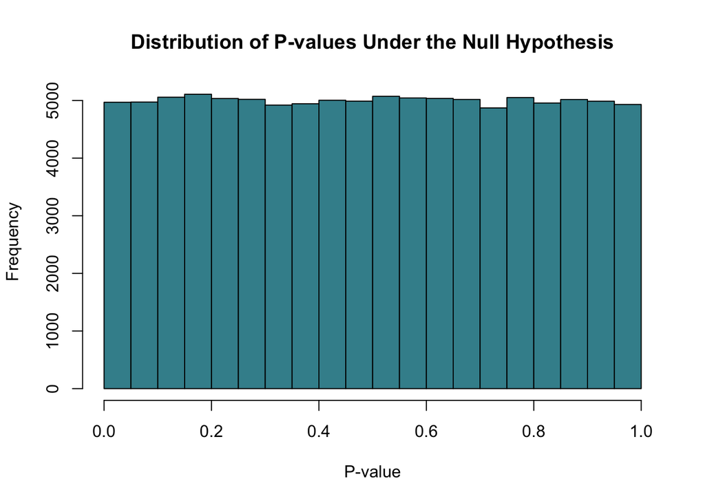

```r
set.seed <- 1031
n.sim <- 100000
t.sim <- numeric(n.sim)
n.samp <- 100

for (i in 1:n.sim) {
  X <- rnorm(n.samp, mean = 0, sd = 1)
  Y <- rnorm(n.samp, mean = 0, sd = 1)
  t <- t.test(X, Y)
  t.sim[i] <- t$p.value
}

hist((t.sim), main = "Distribution of P-values Under the Null Hypothesis",
     xlab = "P-value", col = "#3f8f9b")
```

### Table 1: Some P-values and Their Corresponding S-values

```r
pvalue <- c(
  0.99, 0.90, 0.50, 0.25, 0.125, 0.10,
  0.05, 0.025, 0.01, 0.005, 0.0001,
  0.0000003, 0.000000001)
```

### Calculate S-values

```r
svalue <- round((-log2(pvalue)), 2)

table1 <- data.frame(pvalue, svalue)

colnames(table1) <- c("P-value", "S-value")

knitr::kable(table1)
```

| P-value | S-value |
| --- | --- |
| 9.90e-01 | 0.01 |
| 9.00e-01 | 0.15 |
| 5.00e-01 | 1.00 |
| 2.50e-01 | 2.00 |
| 1.25e-01 | 3.00 |
| 1.00e-01 | 3.32 |
| 5.00e-02 | 4.32 |
| 2.50e-02 | 5.32 |
| 1.00e-02 | 6.64 |
| 5.00e-03 | 7.64 |
| 1.00e-04 | 13.29 |
| 3.00e-07 | 21.67 |
| 0.00e+00 | 29.90 |

Valid P-values are uniform under the null hypothesis and their corresponding S-values are exponentially distributed. We run the same simulation as before, but then convert the obtained P-values into S-values.

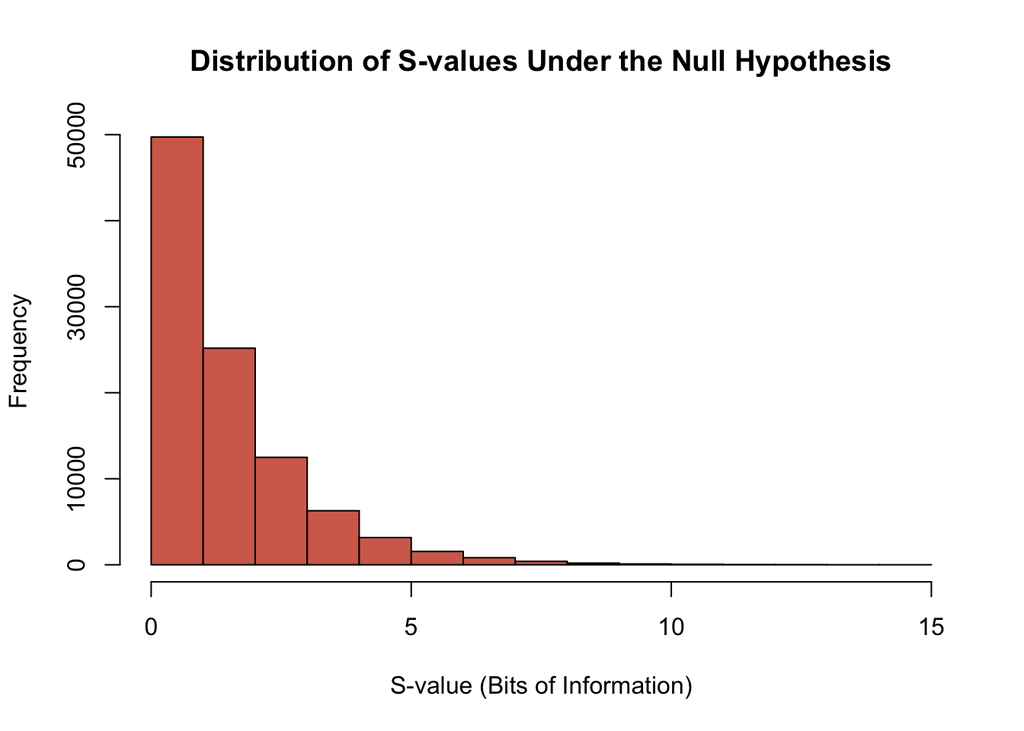

```r
set.seed <- 1031
n.sim <- 100000
t.sim <- numeric(n.sim)
n.samp <- 100

for (i in 1:n.sim) {
  X <- rnorm(n.samp, mean = 0, sd = 1)
  Y <- rnorm(n.samp, mean = 0, sd = 1)
  t <- t.test(X, Y)
  t.sim[i] <- t$p.value
}

hist(-log2(t.sim), main = "Distribution of S-values Under the Null Hypothesis",
     xlab = "S-value (Bits of Information)", col = "#d46c5b")
```

### Frequentist Interval Estimates Refer to the Long-Run Coverage

Here we simulate a study where one group with 100 participants has an average of 100 with a standard deviation of 20 and the second group has the same number of participants but an average of 80 and a standard deviation of 20. We compare them using a t-test and generate 95% intervals several times, specifically 100 times, and then plot them. Since we know the mean difference is 20, we wish to see how often the interval estimates cover this true parameter value.

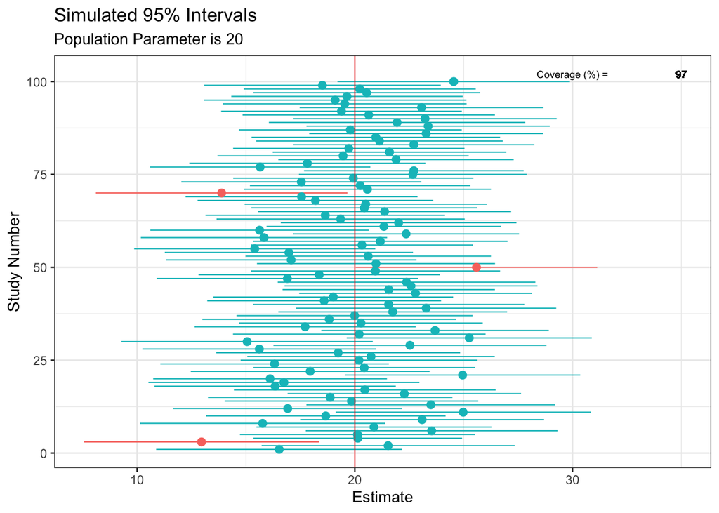

```r
sim <- function() {
  fake <- data.frame((x <- rnorm(100, 100, 20)), (y <- rnorm(100, 80, 20)))
  intervals <- t.test(x = x, y = y, data = fake, conf.level = .95)$conf.int[]
}

set.seed(1031)

z <- replicate(100, sim(), simplify = FALSE)

df <- data.frame(do.call(rbind, z))
df$studynumber <- (1:length(z))
intrvl.limit <- c("lower.limit", "upper.limit", "studynumber")
colnames(df) <- intrvl.limit
df$point <- ((df$lower.limit + df$upper.limit) / 2)
df$covered <- (df$lower.limit <= 20 & 20 <= df$upper.limit)
df$coverageprob <- ((as.numeric(table(df$covered)[2]) / nrow(df) * 100))

library(ggplot2)


ggplot(data = df, aes(x = studynumber, y = point, ymin = lower.limit, ymax = upper.limit)) +
  geom_pointrange(mapping = aes(color = covered), size = .40) +
  geom_hline(yintercept = 20, lty = 1, color = "red", alpha = 0.5) +
  coord_flip() +
  labs(
    title = "Simulated 95% Intervals",
    x = "Study Number",
    y = "Estimate",
    subtitle = "Population Parameter is 20"
  ) +
  theme_bw() + # use a white background
  theme(legend.position = "none") +
  annotate(
    geom = "text", x = 102, y = 30,
    label = "Coverage (%) =", size = 2.5, color = "black"
  ) +
  annotate(
    geom = "text", x = 102, y = 35,
    label = df$coverageprob, size = 2.5, color = "black"
  )
```

Taken from the Brown et al. data [DOI: 10.1001/jama.2017.3415](https://doi.org/10.1001/jama.2017.3415)

Here we take the reported statistics from the Brown et al. data in order to run statistical tests of different test hypotheses and use those results to construct various functions.

Calculate the standard errors from the point estimate and the confidence (compatibility) limits

```r
se <- log(2.59 / 0.997) / 3.92

logUL <- log(2.59)
logLL <- log(0.997)

logpoint <- log(1.61)

logpoint + (1.96 * se)
```

```
## [1] 0.9535654
```

```r
logpoint - (1.96 * se)
```

```
## [1] -0.001097013
```

### Table 2: P-values, S-values, and Relative Likelihood Ratios (LR) for Targeted Test Hypotheses About Hazard Ratios (HR) for [Brown et al.](https://doi.org/10.1001/jama.2017.3415)

### Compute P-values, S-values, and Likelihood Ratios For [Brown et al.](https://doi.org/10.1001/jama.2017.3415)

```r
testhypothesis <- c(
  "Halving of hazard", "No effect (null)", "Point estimate",
  "Doubling of hazard", "Tripling of hazard", "Quintupling of hazard"
)
hazardratios <- c(0.5, 1, 1.61, 2, 3, 5)
pvals <- c(1.6e-06, 0.05, 1.00, 0.37, 0.01, 3.2e-06)
svals <- round(-log2(pvals), 3)
lr <- round(c(
  exp((((log(0.5 / 1.61)) / se)^2) / (2)),
  exp((((log(1 / 1.61)) / se)^2) / (2)),
  exp((((log(1.61 / 1.61)) / se)^2) / (2)),
  exp((((log(2 / 1.61)) / se)^2) / (2)),
  exp((((log(3 / 1.61)) / se)^2) / (2)),
  exp((((log(5 / 1.61)) / se)^2) / (2))
), 3)

LR <- formatC(lr, format = "e", digits = 2)

table2 <- data.frame(testhypothesis, hazardratios,
                     pvals, svals, LR)


colnames(table2) <- c("Test Hypothesis", "Hazard Ratios",
                      "P-values", "S-values", "Likelihood Ratio Statistics")

knitr::kable(table2)
```

| Test Hypothesis | Hazard Ratios | P-values | S-values | Likelihood Ratio Statistics |
| --- | --- | --- | --- | --- |
| Halving of hazard | 0.50 | 1.6e-06 | 19.253 | 1.02e+05 |
| No effect (null) | 1.00 | 5.0e-02 | 4.322 | 6.77e+00 |
| Point estimate | 1.61 | 1.0e+00 | 0.000 | 1.00e+00 |
| Doubling of hazard | 2.00 | 3.7e-01 | 1.434 | 1.49e+00 |
| Tripling of hazard | 3.00 | 1.0e-02 | 6.644 | 2.62e+01 |
| Quintupling of hazard | 5.00 | 3.2e-06 | 18.253 | 5.03e+04 |

### Plot the point estimate and 95% compatibility interval using `ggplot2`

```r
label <- ("Brown et al.")
point <- (1.61)
lower <- (0.997)
upper <- (2.59)

df <- data.frame(label, point,
                 lower, upper)
```

Install and load `ggplot2` R package if not already done so

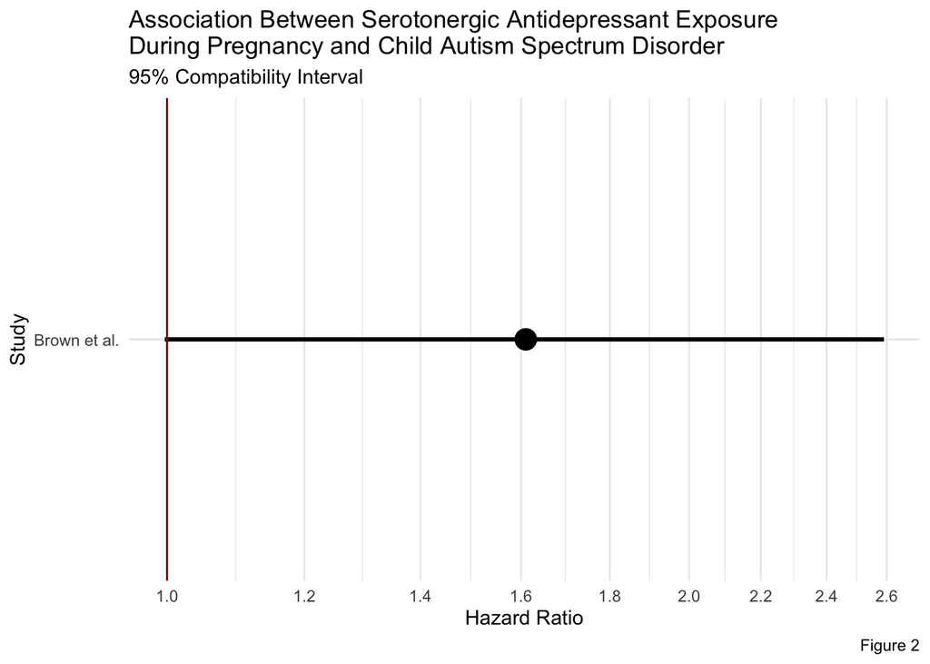

```r
library(ggplot2)

ggplot(data = df, mapping = aes(x = label, y = point, ymin = lower, ymax = upper)) +
  geom_pointrange(color = "black", size = 1.1) +
  geom_hline(yintercept = 1, lty = 1, color = "dark red") +
  coord_flip() +
  scale_y_log10(breaks = scales::pretty_breaks(n = 10)) +
  labs(
    title = "Association Between Serotonergic Antidepressant Exposure \nDuring Pregnancy and Child Autism Spectrum Disorder",
    subtitle = "95% Compatibility Interval",
    caption = "Figure 2",
    x = "Study",
    y = "Hazard Ratio"
  ) +
  theme_minimal()
```

Compute and plot the consonance and surprisal functions using `concurve` R package.

Install and load `concurve` R package if not already done so

```r
library(concurve)
```

Enter point estimates and compatibility limits and produce all possible intervals + P-values + S-values. This is calculated assuming normality.

```r
df <- curve_rev(point = 1.61, LL = 0.997, UL = 2.59,
                measure = "ratio", steps = 10000)
```

Stored in data frame “df”

### Figure 3: P-value (Compatibility) Function

Plot the P-value (Compatibility) function of the [Brown et al.](https://doi.org/10.1001/jama.2017.3415) data with `ggplot2` graphics.

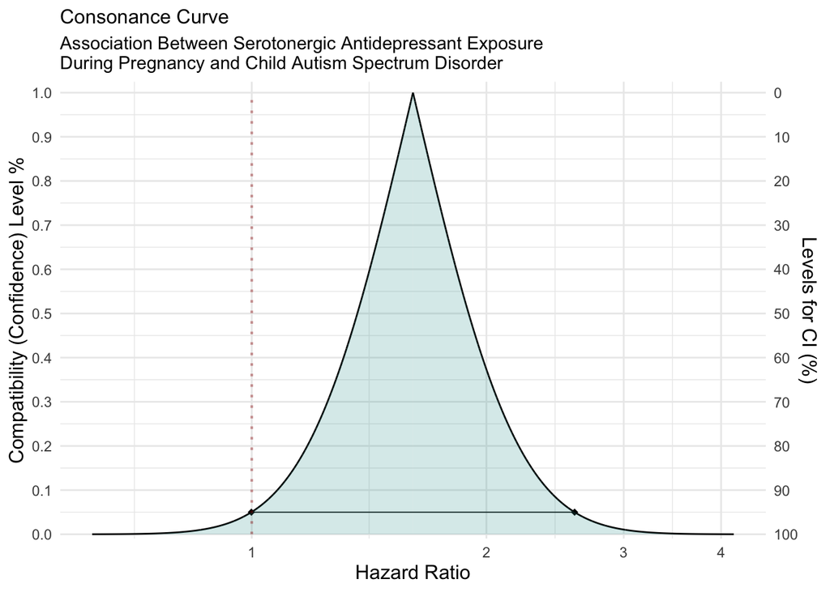

```r
ggcurve(
  data = df[[1]], type = "c",  measure = "ratio", nullvalue = TRUE,
  title = "P-Value (Compatibility) as a Function of the Hazard Ratio",
  subtitle = "Association Between Serotonergic Antidepressant Exposure \nDuring Pregnancy and Child Autism Spectrum Disorder",
  xaxis = "Hazard Ratio", yaxis = "Compatibility (Confidence) Level %"
)
```

We can also see how consistent these results are with previous studies conducted by the same research group.

```r
curve1 <- curve_rev(point = 1.7, LL = 1.1, UL = 2.6,
                    type = "c", measure = "ratio", steps = 10000)

curve2 <- curve_rev(point = 1.61, LL = 0.997, UL = 2.59,
                    type = "c", measure = "ratio", steps = 10000)
```

```r
lik1 <- curve_rev(point = 1.7, LL = 1.1, UL = 2.6,
                  type = "l", measure = "ratio", steps = 10000)

lik2 <- curve_rev(point = 1.61, LL = 0.997, UL = 2.59,
                  type = "l", measure = "ratio", steps = 10000)
```

Let’s compare the relative likelihood functions from both studies from this research group to see how consistent the results are.

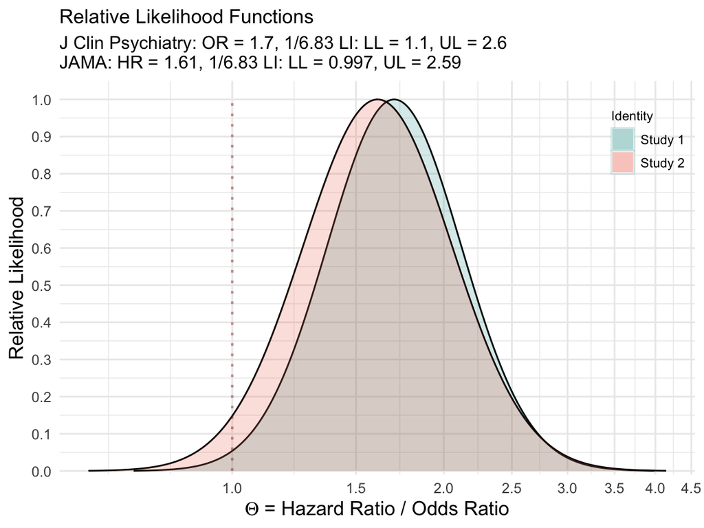

```r
(plot_compare(
  data1 = lik1[[1]], data2 = lik2[[1]],
  type = "l1", measure = "ratio", nullvalue = TRUE,
  title = "Brown et al. 2017. J Clin Psychiatry. vs. \nBrown et al. 2017. JAMA.",
  subtitle = "J Clin Psychiatry: OR = 1.7, 1/6.83 LI: LL = 1.1, UL = 2.6 \nJAMA: HR = 1.61, 1/6.83 LI: LL = 0.997, UL = 2.59", xaxis = expression(Theta ~ "= Hazard Ratio / Odds Ratio")
))
```

and the consonance functions

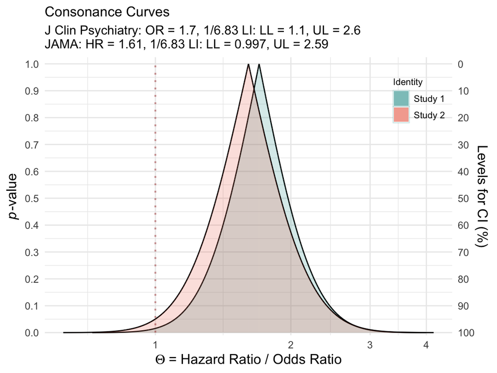

```r
(plot_compare(
  data1 = curve1[[1]], data2 = curve2[[1]],
  type = "c", measure = "ratio", nullvalue = TRUE,
  title = "Brown et al. 2017. J Clin Psychiatry. vs. \nBrown et al. 2017. JAMA.",
  subtitle = "J Clin Psychiatry: OR = 1.7, 1/6.83 LI: LL = 1.1, UL = 2.6 \nJAMA: HR = 1.61, 1/6.83 LI: LL = 0.997, UL = 2.59", xaxis = expression(Theta ~ "= Hazard Ratio / Odds Ratio")
))
```

### Figure 4: S-value (Suprisal) Function

Plot the S-value (Surprisal) function of the [Brown et al.](https://doi.org/10.1001/jama.2017.3415) data with `ggplot2` graphics.

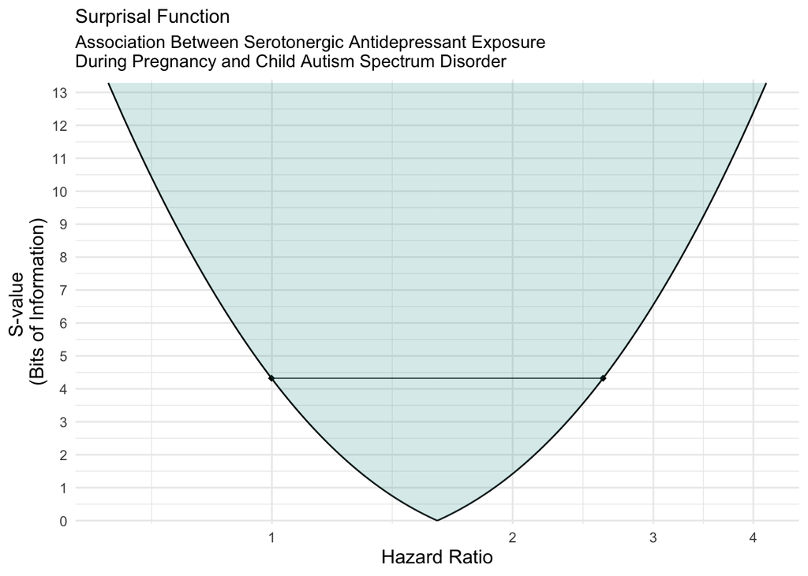

```r
ggcurve(
  data = df[[1]], type = "s",  measure = "ratio", nullvalue = TRUE,
  title = "S-Value (Surprisal) as a Function of the Hazard Ratio",
  subtitle = "Association Between Serotonergic Antidepressant Exposure \nDuring Pregnancy and Child Autism Spectrum Disorder",
  xaxis = "Hazard Ratio", yaxis = "S-value (bits of information)"
)
```

Calculate and Plot Likelihood (Support) Intervals.

```r
hrvalues <- seq(from = 0.65, to = 3.98, by = 0.01)

se <- log(2.59 / 0.997) / 3.92

zscore <- sapply(hrvalues,
            function(i)(log(i / 1.61) / se))
```

### Figure S1: Relative Likelihood MLR

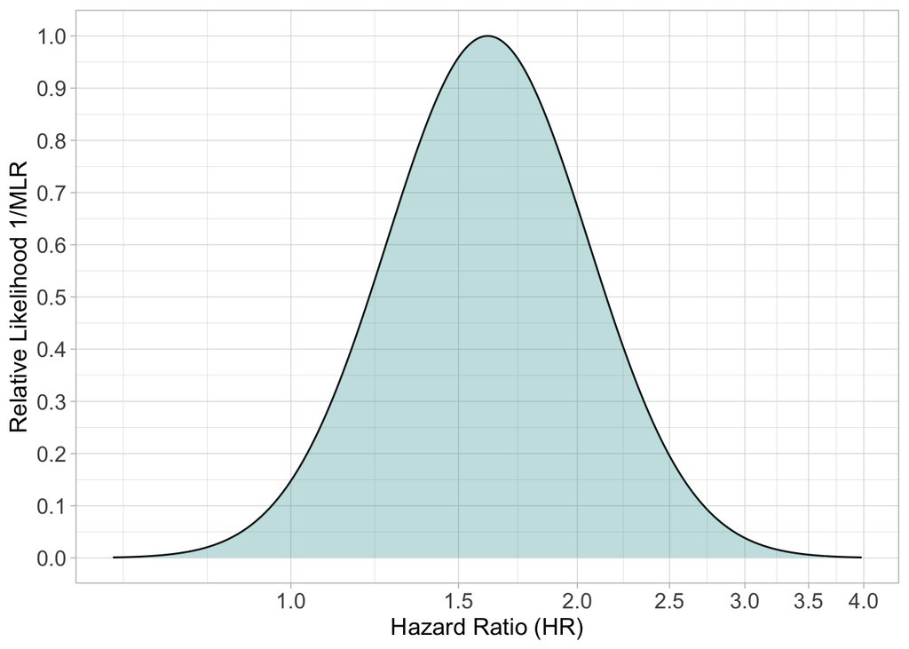

```r
support <- exp((-zscore^2)/2)

likfunction <- data.frame(hrvalues, zscore, support)

ggplot(data = likfunction, mapping = aes(x = hrvalues, y = support)) +
  geom_line() +
  geom_ribbon(aes(x = hrvalues, ymin = min(support), ymax = support),
              fill = "#239a98", alpha = 0.30) +
  labs(
    x = "Hazard Ratio (HR)",
    y = "Relative Likelihood 1/MLR"
  ) +
  theme_light() +
  theme(
    axis.title.x = element_text(size = 13),
    axis.title.y = element_text(size = 13)
  ) +
  scale_x_log10(breaks = scales::pretty_breaks(n = 10)) +
  scale_y_continuous(breaks = scales::pretty_breaks(n = 10)) +
  theme(text = element_text(size = 15)) +
  theme(
    plot.title = element_text(size = 16),
    plot.subtitle = element_text(size = 12),
    plot.caption = element_text(size = 8))
```

upward-concave parabola $Z^{2}/2$ = $-ln(MLR)$ which is the likelihood analog of the S-value function

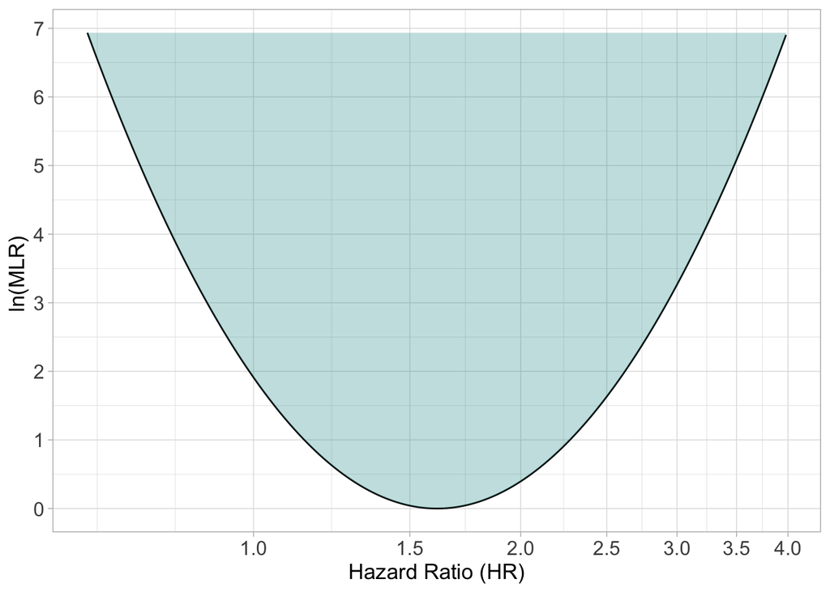

```r
support <- (zscore^2)/2

likfunction <- data.frame(hrvalues, zscore, support)

ggplot(data = likfunction, mapping = aes(x = hrvalues, y = support)) +
  geom_line() +
  geom_ribbon(aes(x = hrvalues, ymin = support, ymax = max(support)),
              fill = "#239a98", alpha = 0.30) +
  labs(
    x = "Hazard Ratio (HR)",
    y = "ln(MLR) "
  ) +
  theme_light() +
  theme(
    axis.title.x = element_text(size = 13),
    axis.title.y = element_text(size = 13)
  ) +
  scale_x_log10(breaks = scales::pretty_breaks(n = 10)) +
  scale_y_continuous(breaks = scales::pretty_breaks(n = 10)) +
  theme(text = element_text(size = 15)) +
  theme(
    plot.title = element_text(size = 16),
    plot.subtitle = element_text(size = 12),
    plot.caption = element_text(size = 8))
```

### Figure S2: Deviance Statistics -2ln(MLR)

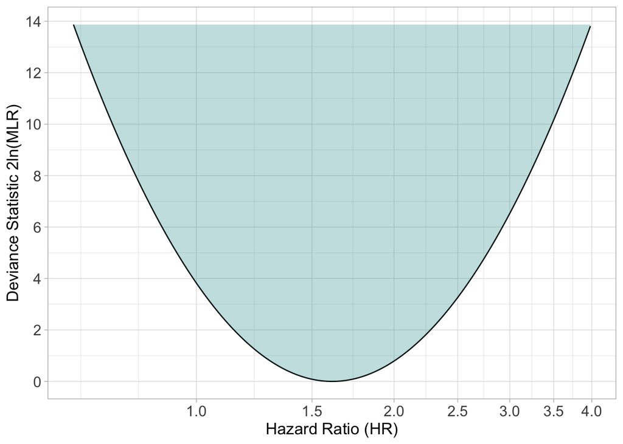

```r
support <- (zscore^2)

likfunction <- data.frame(hrvalues, zscore, support)

ggplot(data = likfunction, mapping = aes(x = hrvalues, y = support)) +
  geom_line() +
  geom_ribbon(aes(x = hrvalues, ymin = support, ymax = max(support)),
              fill = "#239a98", alpha = 0.30) +
  labs(
    x = "Hazard Ratio (HR)",
    y = " Deviance Statistic 2ln(MLR) "
  ) +
  theme_light() +
  theme(
    axis.title.x = element_text(size = 13),
    axis.title.y = element_text(size = 13)
  ) +
  scale_x_log10(breaks = scales::pretty_breaks(n = 10)) +
  scale_y_continuous(breaks = scales::pretty_breaks(n = 10)) +
  theme(text = element_text(size = 15)) +
  theme(
    plot.title = element_text(size = 16),
    plot.subtitle = element_text(size = 12),
    plot.caption = element_text(size = 8))
```